# ST

Marta Venegas Pardo

6/2/2022

## Modelos estadísticos clásicos

### Lectura y descripción de los datos

### Modelo de Regresión Lineal General

### Análisis de Series Temporales

Se consideró aplicar un análisis de series temporales debido a la estructura de los datos ya que este tipo de análisis contempla la estructura temporal de los datos. Como ya se avanzó en el desarrollo teórico, aplicaremos la metodología Box-Jenkis, la cual tiene en cuenta la dependencia existente de los datos, construyendo así un modelo ARIMA.

#### Creación ST y representación de los datos

```
##      p1   p2   p3   p4   p5   p6   p7
## 31                          2039  206
## 32 2408 1945 1638 1788 1773 1995  184
## 33 2130 1508 1688 1605 2030  398  258
## 34 2491 1947 1437 1460 1639 1983  155
## 35 2294 1928 1843 1766 1812 2495  184
## 36 2380 1978 2279 2015 2143 2325  237
## 37 2493 1977 2149 2050  492 3078  239
## 38 2485 2218 2256 1969 1959 2480  231
## 39 2124 2095 2100 1517 2904 2683  164
## 40 2608 2069 2056 2176 2419 2968  168
## 41 2265 2393 2000 2126 2245 2930  210
## 42  400 2962 2492 8011 2333 2932  192
## 43 2248 1825 1667 1811 2400 2601  258
## 44 2381 2485 2386 2528 2435 2558  171
## 45 2423 2175 2307 2297 2357 2621  134
## 46 2386 2000 2063 2120 2481 2950  163
## 47 2397 2003 1866 2208 2242 2565  149
## 48 2133 2171 2264 2008 2657 3040  126
## 49 2489 2242 2232 2009 2348 2889  123
## 50 2362  309 2440 2206 2476 2860  107
## 51 2143 2159 1601 6969 2154 2820  261
## 52 2103 2282 2794 2090    1  340  348
## 53 3004 2770 2637 2013    1 2642  191
## 54 2951 2898   30 2599 2884 2546  161
## 55 2492 2496 2116 2058 2607 2859   99
## 56 2399 2153 1830 2100 2433 2992  118
## 57 2407 2094 2373 2306 2621 2966
```

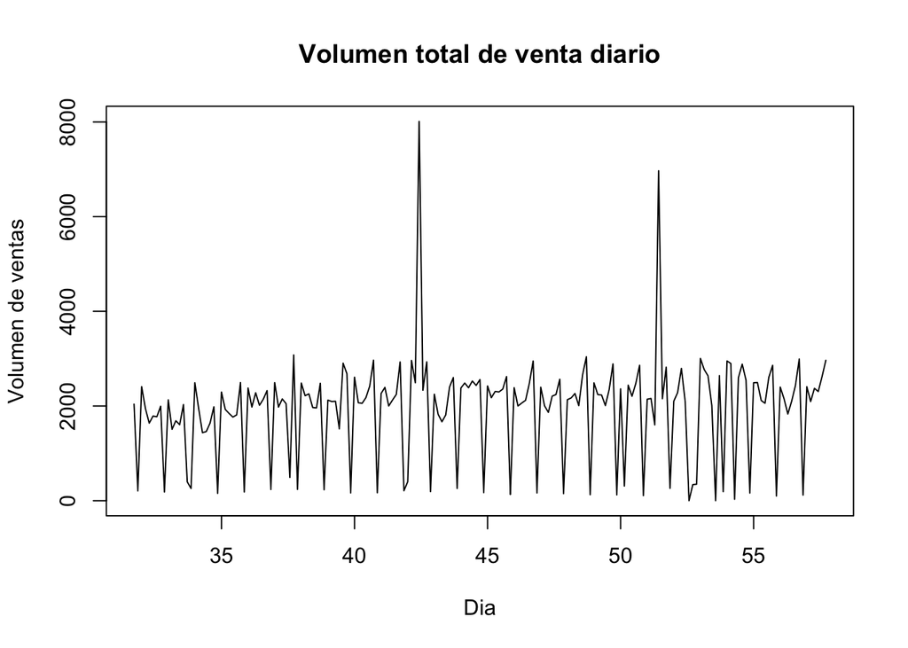

#### Transformación de BoxCox para estabilizar la varianza

Para ello, haremos uso de la familia de transformaciones Box-Cox haciendo uso de la librería *TSA*.

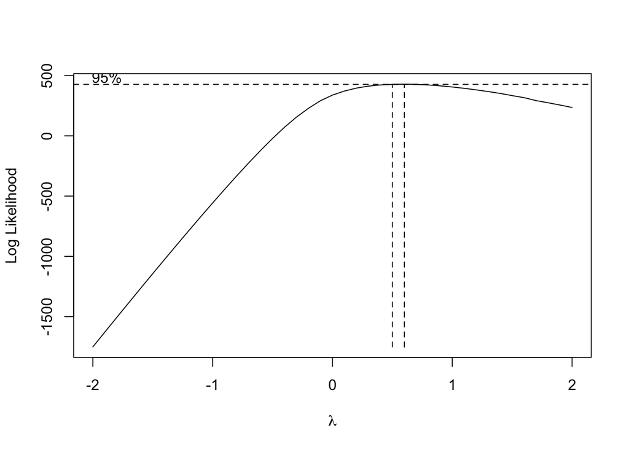

```
## $lambda
##  [1] -2.0 -1.9 -1.8 -1.7 -1.6 -1.5 -1.4 -1.3 -1.2 -1.1 -1.0 -0.9 -0.8 -0.7 -0.6
## [16] -0.5 -0.4 -0.3 -0.2 -0.1  0.0  0.1  0.2  0.3  0.4  0.5  0.6  0.7  0.8  0.9
## [31]  1.0  1.1  1.2  1.3  1.4  1.5  1.6  1.7  1.8  1.9  2.0
##
## $loglike
##  [1] -1750.74862 -1628.05536 -1505.86957 -1384.24922 -1263.26274 -1142.99176
##  [7] -1023.53460  -905.01117  -787.56959  -671.39561  -556.72644  -443.86983
## [13]  -333.23509  -225.38633  -121.12249   -21.60492    71.46347   155.75123
## [19]   228.67745   291.22533   337.97702   371.56055   396.06847   412.33876
## [25]   422.13879   426.85413   428.74320   426.71600   421.88487   414.62777
## [31]   405.26612   394.08168   381.31824   367.17754   351.81682   333.57869
## [37]   316.49180   292.11518   274.28100   255.25637   235.18542
##
## $mle
## [1] 0.6
##
## $ci
## [1] 0.5 0.6
```

La función *BoxCox.ar* sugiere un óptimo de lambda = 0.6, con un intervalo de confianza al 95%: (0.5,0.6). Se necesita una transformación sencilla y comprensible, por lo que se ha obtado por tomar el valor $\lambda=1/2$.

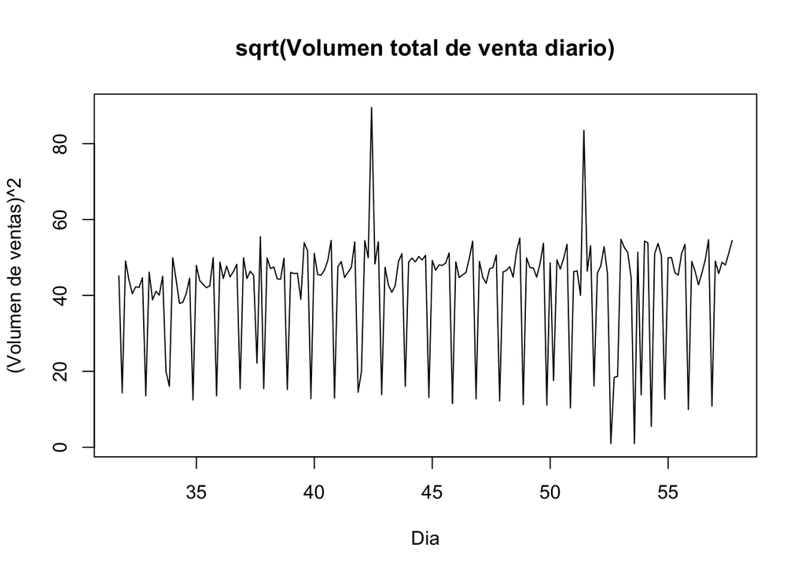

#### Transformaciones para estabilizar la media

Vamos a estudiar si el motivo de la no estacionalidad de los datos en media se debe a que se trata de un proceso integrado

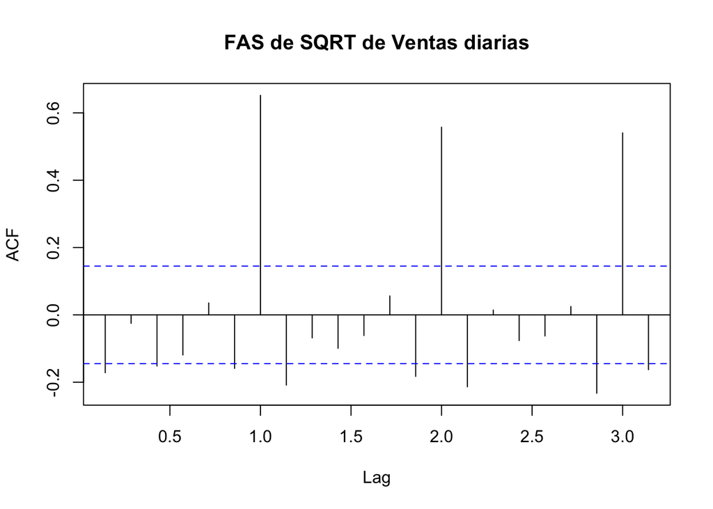

La FAS muestral decrece de manera lenta, indicando que estamos ante un modelo integrado. Debido a esta situación, hacemos una diferencia regular de la serie.

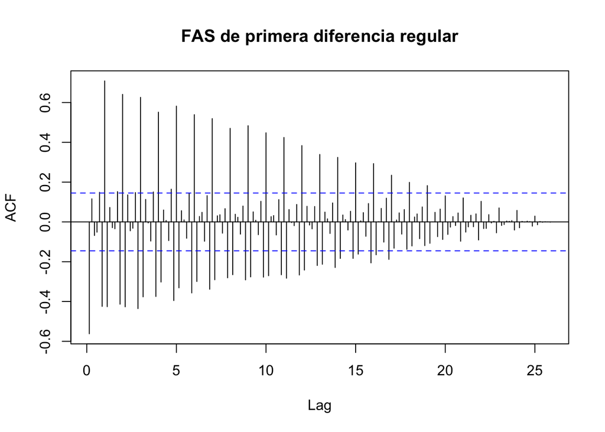

Ahora apreciamos como las autocorrelaciones de período 7 decrecen lentamente, haciendo evidente la necesidad de hacer una diferencia estacional:

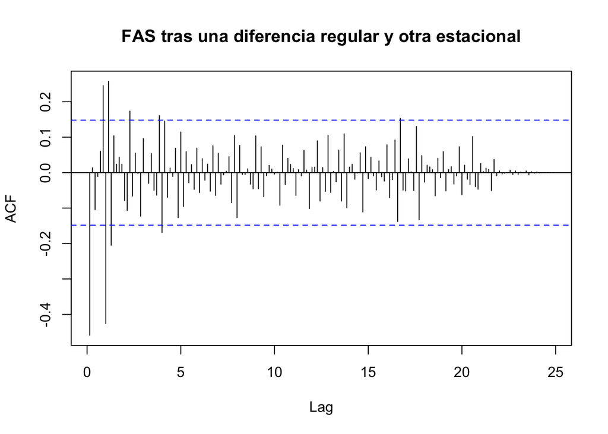

Ahora la función de autocorrelación muestral corresponde a la de un proceso estacionario. Por último, representamos gráficamente la serie diferenciada:

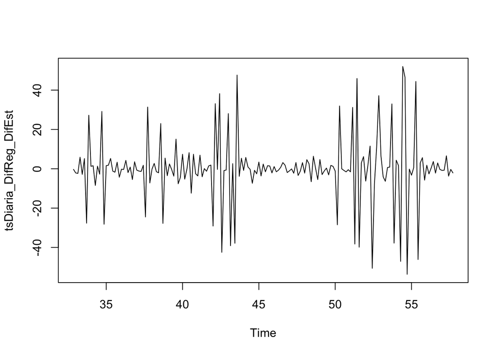

Tiene forma de muelle, por lo que estamos ante un proceso estacionario.

#### Contraste de estacionariedad

Aplicamos el test de raíz unitaria de Dikey-Fuller, donde se contrasta la estacionariedad de los datos a través del siguiente contraste de hipótesis:

$$\left\{
\begin{array}{ll}
H_{0}: & \text{El polinomio autoregresivo tiene una raíz unitaria} \\
H_{1}: & \text{Todas las raíces del polinomio autoregresivo son estacionarias}
\end{array}
\right.$$

Con ayuda de la librería *tseries*.

```
##
##  Augmented Dickey-Fuller Test
##
## data:  tsDiaria_DifReg_DifEst
## Dickey-Fuller = -6.6087, Lag order = 5, p-value = 0.01
## alternative hypothesis: stationary
```

El p-valor del test: $p-valor=0.01 < 0.05= \alpha$, y por tanto, no tenemos evidencias significativas para asumir que el polinomio autoregresivo tiene alguna raíz unitaria, y por tanto, la serie es estacionaria.

#### Identificación de la estructura ARIMA de la serie

Trataremos de identificar la estructura ARIMA a través de la función de autocorrelación simple (FAC) y de la función de autocorrelación parcial (FAP).

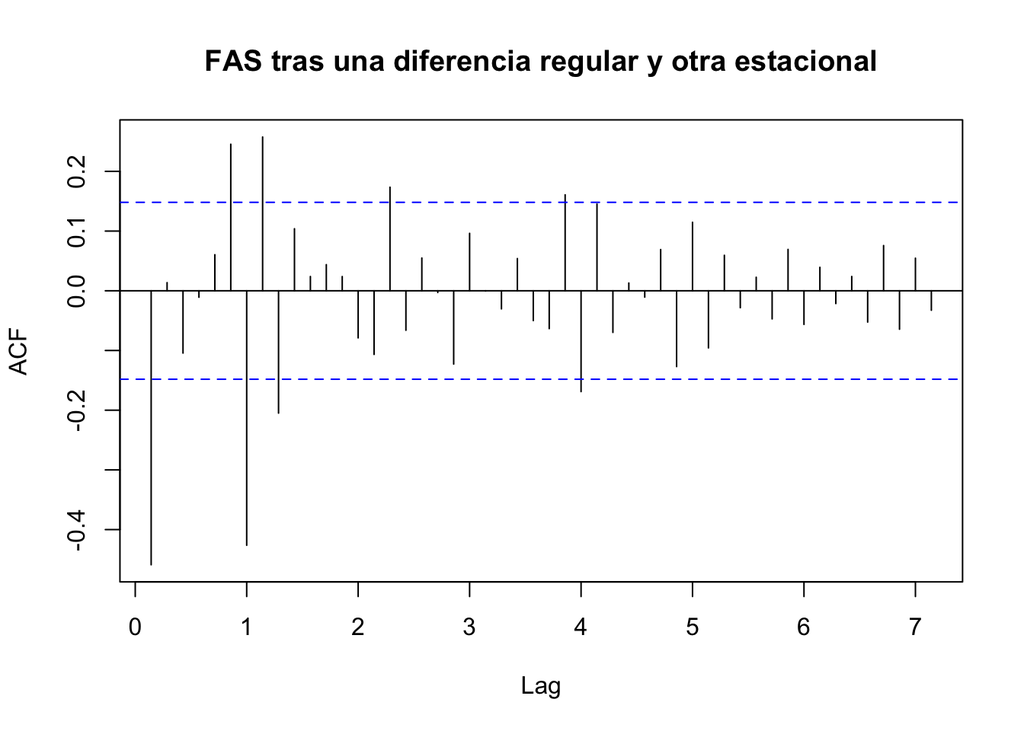

- Parte regular: En los primeros retardos observamos una autocorrelación, lo que podría indicar que el modelo tiene una estructura MA(1) en la parte regular.
- Parte estacional: En los retardos estacionales, observamos una autocorrelación en el primer retardo, por lo que parecería que la parte estacional también tiene una estructura MA(1).

Vamos a comprobar estos supuestos con la FAP.

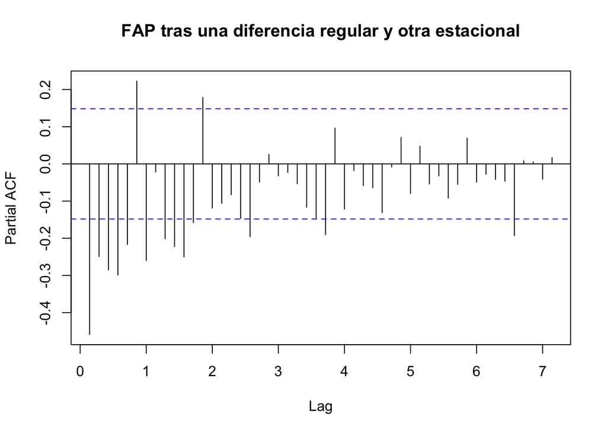